# Análisis de Cluster

Estudio R

Noviembre de 2017

# Contenido

- Generalidades del análisis de Cluster
- Objetivos del Análisis de CLuster
- Algunas aplicaciones
- Medidas de similaridad
- Métodos de agrupamiento
- Ejemplo e implementación en R
- Datos de gorriones
- Dendrogramas
- Componentes principales + Cluster
- Proyecciones en el plano con los Cluster

# Aálisis de Cluster o agrupamiento

- Es un procedimiento estadístico que parte de un conjunto de datos que contiene información sobre una muestra de individuos e intenta reorganizarlos en grupos relativamente homogéneos a los que se llama conglomerados (clusters).
- Un conglomerado, grupo o clase es un conjunto de individuos con características similares.
- Es necesario una medida que indique la similaridad entre individuos u objetos.
- Es necesario un método para obtener los grupos

# Objetivos del Cluster

- Busca particionar un cojunto de objetos en grupos, de tal forma que los objetos de un mismo grupo sean similares y los objetos de grupos distintos sean diferentes.

# Algunas aplicaciones

- Biología
- Estudios sociales
- Estudios económicos
- Tencnología
- Perfil de clientes
- Entre otros

# Medidas de similaridad

- Métricas –> Distancias
- Escala nominal –> Coeficientes de asociación
- Coeficientes de correlación

**Algunas de las distancias utilizadas son:**

- *Distancia Euclidea*
  $$dij = d(Xi, Xj) = \sqrt{\sum_{k=1}^{p} (Xik - Xjk)^2}$$
- *Distancia de Mahalanobis*
- *Distancia de Manhattan*
- *Distancia de Minkowski*

**Algunas de los coeficientes de asociación utilizados son:**

- *Coeficiente de asociación simple*
- *Coeficiente de Jacard*
- *Coeficiente de Rogers y Tanimoto*
- *Coeficiente de Sorense o Dice*
- *Coeficiente de Sokal y Sneath*
- *Coeficiente de Hamann*

**Para las distancias se cumple que:**

- La distancia $d(x,y) \geq 0$.
- La distancia de un objeto $d(x,x) = 0$
- *Desigualdad triangular:* la suma de dos coordenadas (`distancias`) debe ser mayor o igual al promedio
  $$d(x,y)\leq d(x,z) + d(y,z)$$
- *Simetria:* $d(x,y) = d(y,x)$

# Métodos de agrupamiento

- Métodos jerarquicos
- Métodos no jerarquicos o de partición
- Métodos de nubes dinámicas
- Métodos de clasificación difusa
- Herramientas gráficas

**Los métodos jerarquicos se clasifican en:**

- Aglomerativos
- Desaglomerativos

**Algunos de los métodos jerarquicos aglomerativos son:**

- Método de enlace simple o vecino más cercano
- Metodo de enlace completo o vecino más lejano
- Método de enlace promedio
- Método de Ward

# Ejemplo e implementación en R

**Lectura de datos:**

```r
datos <- read.csv(file = "Gorriones.csv", dec = ",")
head(datos, n = 5)
```

```
##   Sexo Edad Sobrevivio LongitudTotal ExteAlas Peso LonPicoCabe LonHumero LonFemur LonTibTarso
## 1    m    a         SI           154      241 24.5        31.2     0.687    0.668       1.022
## 2    m    a         NO           165      240 26.5        31.0     0.738    0.704       1.095
## 3    m    a         NO           160      245 26.1        32.0     0.736    0.709       1.109
## 4    m    a         SI           160      252 26.9        30.8     0.736    0.709       1.180
## 5    m    a         SI           155      243 26.9        30.6     0.733    0.704       1.151
##   AncCraneo LonQuilla
## 1     0.587     0.830
## 2     0.606     0.847
## 3     0.611     0.842
## 4     0.602     0.841
## 5     0.602     0.846
```

# Dendrograma (enlace completo o vecino más lejano)

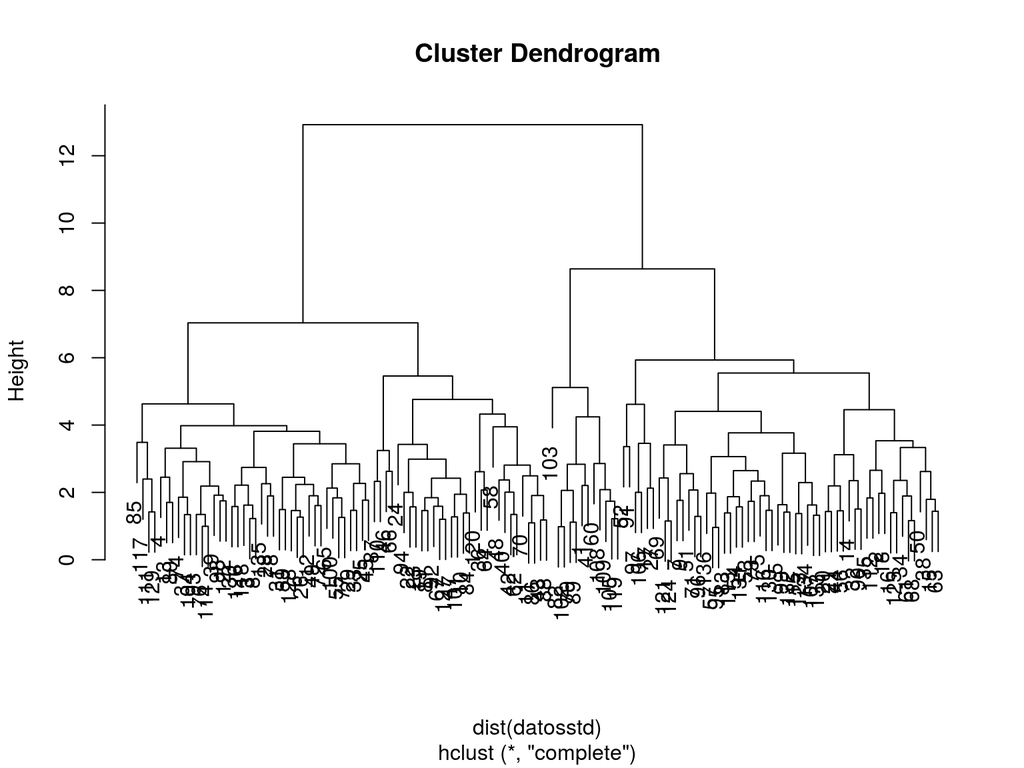

```r
datosstd <- data.frame(scale(datos[, 4:12]))
cluster1 <- hclust(dist(datosstd))
plot(cluster1)
```

**Asignando grupos (del cluster1) a la base de datos inicial**

```r
datos$grupo <- cutree(cluster1, 5)
head(datos, n = 10)
```

```
##    Sexo Edad Sobrevivio LongitudTotal ExteAlas Peso LonPicoCabe LonHumero LonFemur LonTibTarso
## 1     m    a         SI           154      241 24.5        31.2     0.687    0.668       1.022
## 2     m    a         NO           165      240 26.5        31.0     0.738    0.704       1.095
## 3     m    a         NO           160      245 26.1        32.0     0.736    0.709       1.109
## 4     m    a         SI           160      252 26.9        30.8     0.736    0.709       1.180
## 5     m    a         SI           155      243 26.9        30.6     0.733    0.704       1.151
## 6     m    a         NO           161      249 25.6        32.3     0.743    0.718       1.128
## 7     m    a         SI           154      245 24.3        31.7     0.741    0.688       1.146
## 8     m    a         NO           162      246 25.9        32.3     0.738    0.709       1.135
## 9     m    a         SI           156      247 24.1        31.5     0.715    0.706       1.129
## 10    m    a         NO           163      250 25.5        32.5     0.752    0.731       1.197
##    AncCraneo LonQuilla grupo
## 1      0.587     0.830     1
## 2      0.606     0.847     2
## 3      0.611     0.842     3
## 4      0.602     0.841     3
## 5      0.602     0.846     2
## 6      0.602     0.828     3
## 7      0.584     0.839     2
## 8      0.607     0.869     3
## 9      0.575     0.821     2
## 10     0.623     0.888     4
```

**Resumen numérico para cada grupo**

```r
lapply(split(datos[,4:12], datos$grupo), summary)
```

```
## $`1`
##  LongitudTotal      ExteAlas          Peso        LonPicoCabe      LonHumero         LonFemur
##  Min.   :152.0   Min.   :230.0   Min.   :22.60   Min.   :30.10   Min.   :0.6590   Min.   :0.6530
##  1st Qu.:153.0   1st Qu.:234.2   1st Qu.:23.10   1st Qu.:30.38   1st Qu.:0.6800   1st Qu.:0.6635
##  Median :154.5   Median :237.0   Median :23.30   Median :30.55   Median :0.6860   Median :0.6725
##  Mean   :154.3   Mean   :236.2   Mean   :23.61   Mean   :30.64   Mean   :0.6871   Mean   :0.6739
##  3rd Qu.:155.2   3rd Qu.:238.2   3rd Qu.:24.52   3rd Qu.:30.98   3rd Qu.:0.6957   3rd Qu.:0.6837
##  Max.   :157.0   Max.   :241.0   Max.   :24.70   Max.   :31.20   Max.   :0.7060   Max.   :0.7020
##   LonTibTarso      AncCraneo        LonQuilla
##  Min.   :1.011   Min.   :0.5510   Min.   :0.7340
##  1st Qu.:1.037   1st Qu.:0.5840   1st Qu.:0.7698
##  Median :1.045   Median :0.5875   Median :0.7770
##  Mean   :1.069   Mean   :0.5847   Mean   :0.7805
##  3rd Qu.:1.107   3rd Qu.:0.5905   3rd Qu.:0.7943
##  Max.   :1.156   Max.   :0.5990   Max.   :0.8300
##
## $`2`
##  LongitudTotal      ExteAlas          Peso        LonPicoCabe      LonHumero         LonFemur
##  Min.   :153.0   Min.   :235.0   Min.   :23.20   Min.   :30.30   Min.   :0.6890   Min.   :0.6620
##  1st Qu.:156.0   1st Qu.:240.0   1st Qu.:24.20   1st Qu.:31.00   1st Qu.:0.7150   1st Qu.:0.6947
##  Median :158.5   Median :244.0   Median :24.75   Median :31.40   Median :0.7260   Median :0.7050
##  Mean   :158.6   Mean   :242.7   Mean   :24.88   Mean   :31.27   Mean   :0.7246   Mean   :0.7045
##  3rd Qu.:161.0   3rd Qu.:246.0   3rd Qu.:25.55   3rd Qu.:31.50   3rd Qu.:0.7330   3rd Qu.:0.7130
##  Max.   :166.0   Max.   :251.0   Max.   :27.50   Max.   :32.40   Max.   :0.7520   Max.   :0.7350
##   LonTibTarso      AncCraneo        LonQuilla
##  Min.   :1.073   Min.   :0.5750   Min.   :0.7810
##  1st Qu.:1.104   1st Qu.:0.5907   1st Qu.:0.8027
##  Median :1.123   Median :0.6000   Median :0.8305
##  Mean   :1.120   Mean   :0.5991   Mean   :0.8288
##  3rd Qu.:1.131   3rd Qu.:0.6082   3rd Qu.:0.8492
##  Max.   :1.175   Max.   :0.6200   Max.   :0.8920
##
## $`3`
##  LongitudTotal      ExteAlas          Peso        LonPicoCabe      LonHumero         LonFemur
##  Min.   :155.0   Min.   :239.0   Min.   :24.00   Min.   :30.80   Min.   :0.7090   Min.   :0.6990
##  1st Qu.:158.0   1st Qu.:245.0   1st Qu.:25.25   1st Qu.:31.75   1st Qu.:0.7310   1st Qu.:0.7097
##  Median :160.0   Median :247.0   Median :25.95   Median :32.05   Median :0.7390   Median :0.7170
##  Mean   :159.8   Mean   :246.7   Mean   :25.80   Mean   :32.01   Mean   :0.7387   Mean   :0.7207
##  3rd Qu.:162.0   3rd Qu.:248.0   3rd Qu.:26.30   3rd Qu.:32.30   3rd Qu.:0.7445   3rd Qu.:0.7332
##  Max.   :165.0   Max.   :253.0   Max.   :27.60   Max.   :33.00   Max.   :0.7660   Max.   :0.7510
```

[output cut: 24 more lines]

```
## $`5`
##  LongitudTotal      ExteAlas          Peso        LonPicoCabe      LonHumero         LonFemur
##  Min.   :156.0   Min.   :236.0   Min.   :23.60   Min.   :29.80   Min.   :0.6900   Min.   :0.6660
##  1st Qu.:158.2   1st Qu.:239.8   1st Qu.:23.98   1st Qu.:29.90   1st Qu.:0.7045   1st Qu.:0.6680
##  Median :159.0   Median :244.5   Median :25.40   Median :30.25   Median :0.7100   Median :0.6720
##  Mean   :159.0   Mean   :243.5   Mean   :25.17   Mean   :30.30   Mean   :0.7100   Mean   :0.6775
##  3rd Qu.:159.8   3rd Qu.:247.0   3rd Qu.:26.07   3rd Qu.:30.68   3rd Qu.:0.7155   3rd Qu.:0.6820
##  Max.   :162.0   Max.   :250.0   Max.   :26.80   Max.   :30.90   Max.   :0.7300   Max.   :0.7030
##   LonTibTarso      AncCraneo        LonQuilla
##  Min.   :1.067   Min.   :0.5630   Min.   :0.7490
##  1st Qu.:1.082   1st Qu.:0.5763   1st Qu.:0.8117
##  Median :1.091   Median :0.5835   Median :0.8200
##  Mean   :1.088   Mean   :0.5828   Mean   :0.8235
##  3rd Qu.:1.097   3rd Qu.:0.5893   3rd Qu.:0.8290
##  Max.   :1.103   Max.   :0.6020   Max.   :0.9110
```

# Componentes principales + Cluster

```r
acp <- princomp(datosstd, cor = TRUE)
datos2 <- data.frame(datos, acp$scores[, c(1, 2, 3)])
head(datos2, n = 10)
```

```
##    Sexo Edad Sobrevivio LongitudTotal ExteAlas Peso LonPicoCabe LonHumero LonFemur LonTibTarso
## 1     m    a         SI           154      241 24.5        31.2     0.687    0.668       1.022
## 2     m    a         NO           165      240 26.5        31.0     0.738    0.704       1.095
## 3     m    a         NO           160      245 26.1        32.0     0.736    0.709       1.109
## 4     m    a         SI           160      252 26.9        30.8     0.736    0.709       1.180
## 5     m    a         SI           155      243 26.9        30.6     0.733    0.704       1.151
## 6     m    a         NO           161      249 25.6        32.3     0.743    0.718       1.128
## 7     m    a         SI           154      245 24.3        31.7     0.741    0.688       1.146
## 8     m    a         NO           162      246 25.9        32.3     0.738    0.709       1.135
## 9     m    a         SI           156      247 24.1        31.5     0.715    0.706       1.129
## 10    m    a         NO           163      250 25.5        32.5     0.752    0.731       1.197
##    AncCraneo LonQuilla grupo     Comp.1     Comp.2      Comp.3
## 1      0.587     0.830     1  3.8880757 -1.3522616  0.41603544
## 2      0.606     0.847     2  0.1575123 -1.4096787  0.40722779
## 3      0.611     0.842     3 -0.3388752 -0.4201252  0.77208305
## 4      0.602     0.841     3 -0.7918721 -0.3448695 -0.78499927
## 5      0.602     0.846     2  0.6448564  0.2402161 -0.09755562
## 6      0.602     0.828     3 -0.8439208 -0.0350315 -0.01554790
## 7      0.584     0.839     2  1.1956308  0.8519471 -0.96170268
## 8      0.607     0.869     3 -1.0570477 -0.5649736  0.29651557
## 9      0.575     0.821     2  1.6455690  0.4574013 -1.38797615
## 10     0.623     0.888     4 -2.9531850  0.3580806  0.29672513
```

# Proyecciones en el plano con los Cluster

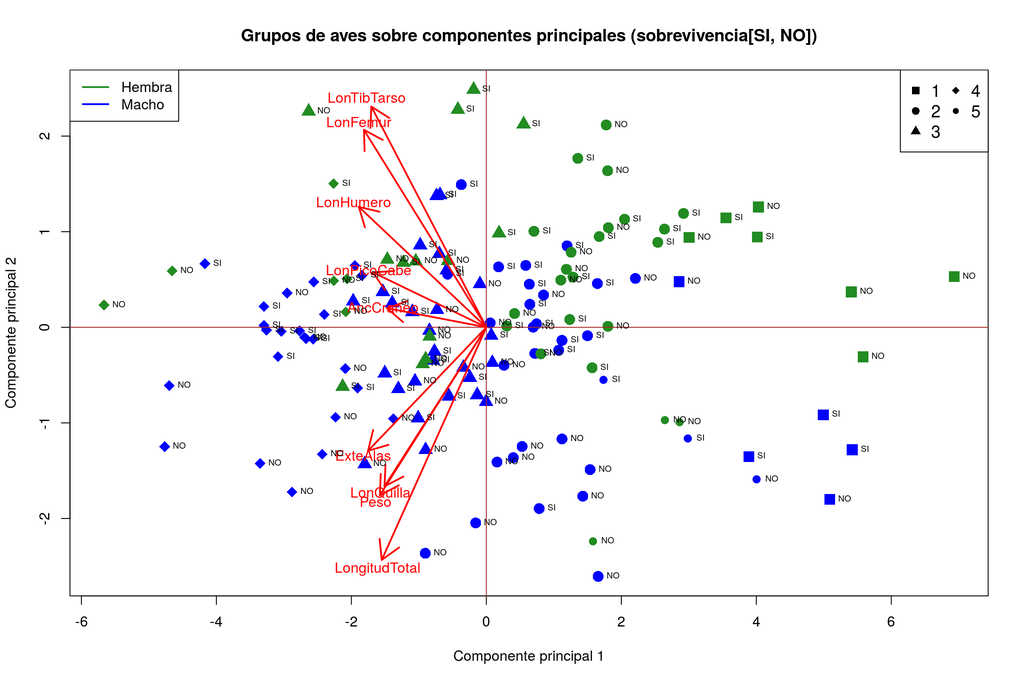

```r
colores <- c("forestgreen", "blue")
simbolos <- c(15, 16, 17, 18, 20)
with(datos2, plot(Comp.1, Comp.2, col = colores[Sexo], pch = simbolos[grupo],
                  xlab = "Componente principal 1", ylab = "Componente principal 2",
                  main = "Grupos de aves sobre componentes principales (sobrevivencia[SI, NO])",
                  cex = 1.7))
legend("topright", legend = 1:5, pch = simbolos, col = "black", ncol = 2, cex = 1.2)
legend("topleft", legend = c("Hembra", "Macho"), col = colores, cex = 1, lty =1, lwd =2)
abline(h = 0, col = "brown")
abline(v = 0, col = "brown")
arrows(0, 0, acp$loadings[, 1]*5, acp$loadings[, 2]*5, col = "red", lwd = 2)
text(acp$loadings[, 1]*5.2, acp$loadings[, 2]*5.2, row.names(acp$loadings), col = "red")
text(datos2$Comp.1, datos2$Comp.2, labels = datos2$Sobrevivio, pos = 4, cex = 0.6)
```

**Sobrevivencia de aves por grupo**

```r
library(dplyr)
datos3 <- datos2 %>%
  group_by(grupo, Sexo, Sobrevivio) %>%
  count() %>%
  arrange(desc(n))

datos3
```

```
## # A tibble: 19 x 4
## # Groups:   grupo, Sexo, Sobrevivio [19]
##    grupo   Sexo Sobrevivio     n
##    <int> <fctr>     <fctr> <int>
##  1     3      m         SI    18
##  2     2      m         NO    14
##  3     2      m         SI    14
##  4     4      m         SI    14
##  5     2      f         SI    11
##  6     4      m         NO    10
##  7     2      f         NO     9
##  8     3      m         NO     9
##  9     3      f         NO     7
## 10     3      f         SI     6
## 11     1      f         NO     5
## 12     4      f         NO     4
## 13     1      m         SI     3
## 14     5      f         NO     3
## 15     1      f         SI     2
## 16     1      m         NO     2
## 17     4      f         SI     2
## 18     5      m         SI     2
## 19     5      m         NO     1
```